# Linkage disequilirium analysis

## Introduction

In the study by [Zhu *et al.*](https://gut.bmj.com/content/early/2023/01/23/gutjnl-2022-329307-0), the number of IVs used in Mendelian Randomization (MR) analyses were always exceeding the number of independent loci, which were identified in the original HEM GWAS study of [Zheng *et al.*](https://gut.bmj.com/content/70/8/1538) This observation raised a concern, because using correlating genetic variants (that is, in linkage disequilibrium) is breaching the core assumptions of the IWV method, which requires to use independent IVs [Burgess *et al.*](https://link.springer.com/article/10.1007/s10654-017-0255-x)

Therefore, we have tested if correlation threshold (r<sup>2</sup> < 0.001) within 10kb window is enough to obtain uncorrelated variants from HEM GWAS summary statistics data.

## Methods

### SNP clumping for LD

Thresholds used by Zhu *et al.*:

1. Association with exposure (HEM GWAS) - P < 5e<sup>-10</sup>;
2. Pruning for linkage disequilibrium (LD) - r<sup>2</sup> < 0.001 within 10kb (1000G EUR);
3. Association with outcome - P < 0.05.

Commonly used thresholds for LD window:

1. Clumping for linkage disequilibrium (LD) - r<sup>2</sup> < 0.001 within 1 Mb (1000G EUR);
2. Clumping for linkage disequilibrium (LD) - r<sup>2</sup> < 0.001 within 10 Mb (1000G EUR);

### Packages

Analyses were performed using R packages [`LDlinkR`](https://CRAN.R-project.org/package=LDlinkR), [`TwoSampleMR`](https://mrcieu.github.io/TwoSampleMR/) and [`tidyverse`](https://www.tidyverse.org).

```r
library(tidyverse)
library(patchwork)
library(TwoSampleMR)
library(LDlinkR)
```

## Analysis and Results

##### SNP clumping for LD in the HEM GWAS data

```r
# set distance thresholds (in kilobases)
kb <- c(10, 1e3)

# data from OpenGWAS db
hem_iv_clumping <- lapply(kb, function(x){
  if(x == 10){
    pval = 5e-10
  } else{
    pval = 5e-8
  }
  extract_instruments(
    "ebi-a-GCST90014033",
    p1 = pval,
    r2 = 0.001,
    kb = x
  )
})
names(hem_iv_clumping) <- c(
  "10 Kb and P < 5e-10 cutoff ",
  "1 Mb and P < 5e-8 cutoff"
)

# number of SNPs after clumping
lapply(hem_iv_clumping, nrow)
```

```
## $`10 Kb and P < 5e-10 cutoff `
## [1] 318
##
## $`1 Mb and P < 5e-8 cutoff`
## [1] 101
```

Here we import DIV and IBS (outcome) GWAS datasets to remove SNPs, which are associated (P < 0.05) with these traits.

```r
# list files to studies
out_file_list <- list(
  "DIV (Schafmayer et al.)" = "../data/GWAS_summary_1-23.dosages.maf_0.01.info_0.4.txt.gz",
  "DIV (Dönertaş et al.)" = "../data/GCST90038682_buildGRCh37.tsv.gz",
  "IBS (Dönertaş et al.)" = "../data/GCST90038626_buildGRCh37.tsv.gz",
  "IBS (Jiang et al.)" = "../data/GCST90044173_buildGRCh37.tsv.gz"
)

# read outcome data
out_dat_list <- lapply(hem_iv_clumping, function(x){
  lapply(seq(out_file_list), function(i){
    if(i==1){
      read_outcome_data(
        snps = x$SNP,
        filename = out_file_list[[i]],
        sep = " ",
        snp_col = "SNP",
        chr_col = "CHR",
        pos_col = "BP",
        beta_col = "BETA",
        se_col = "SE",
        effect_allele_col = "ALLELE1",
        other_allele_col = "ALLELE0",
        eaf_col = "A1FREQ",
        pval_col = "P"
      ) %>%
      # add outcome name
      mutate(
        outcome = names(out_file_list)[i]
        )
      } else {
        read_outcome_data(
          snps = x$SNP,
          filename = out_file_list[[i]],
          sep = "\t",
          snp_col = "variant_id",
          chr_col = "chromosome",
          pos_col = "base_pair_location",
          beta_col = "beta",
          se_col = "standard_error",
          effect_allele_col = "effect_allele",
          other_allele_col = "other_allele",
          eaf_col = "effect_allele_frequency",
          pval_col = "p_value"
        ) %>%
      # add outcome name
      mutate(
        outcome = names(out_file_list)[i]
        )
      }
  })
})

# harmonize data and exclude outcome-associated SNPs (P<0.05)
# as described by Zhu et al.
har_dat_list <- lapply(seq(out_dat_list), function(i){
  lapply(seq(out_dat_list[[i]]), function(j){
    harmonise_data(hem_iv_clumping[[i]], out_dat_list[[i]][[j]]) %>%
      filter(pval.outcome > 0.05 & mr_keep == TRUE)
    }) %>%
    bind_rows() %>%
    select(SNP, chr.exposure) %>%
    distinct()
  })
names(har_dat_list) <- names(out_dat_list)

# number of SNPs used as IVs
lapply(har_dat_list, nrow)
```

```
## $`10 Kb and P < 5e-10 cutoff `
## [1] 301
##
## $`1 Mb and P < 5e-8 cutoff`
## [1] 96
```

```r
# please provide your LDlink token
# copy the token in the following file:
token <- readLines("../data/LDlink_token.txt")

# split SNPs by chrom
snp_list <- lapply(har_dat_list, function(x){
  y <- split(x, x$chr.exposure)
  # filter chr having only one variant
  idx <- lapply(y, function(i) nrow(i)!=1)
  y <- y[unlist(idx)]
  return(y)
})

# retrieve LD
ld_mat_list <- lapply(snp_list, function(i){
  lapply(i, function(x){
    m <- LDmatrix(
      x$SNP,
      pop = "CEU",
      r2d = "r2",
      token = token
      )
    m <- as.matrix(m[,-1])
    m[lower.tri(m, diag = TRUE)] <- NA
    rownames(m) <- colnames(m)
    return(m)
  })
})

# make tabular
ld_mat_tb <- lapply(ld_mat_list, function(i){
  lapply(i, function(x){
    x %>% reshape2::melt(
      varnames = c("SNP1", "SNP2"),
      value.name = "r2"
    )
    }) %>%
  bind_rows(.id = "chr")
  }) %>%
  bind_rows(.id = "dist_cutoff") %>%
  mutate(
    dist_cutoff = factor(
      dist_cutoff, levels = names(hem_iv_clumping)
    ),
    chr = factor(chr, levels = 1:22)
  )
```

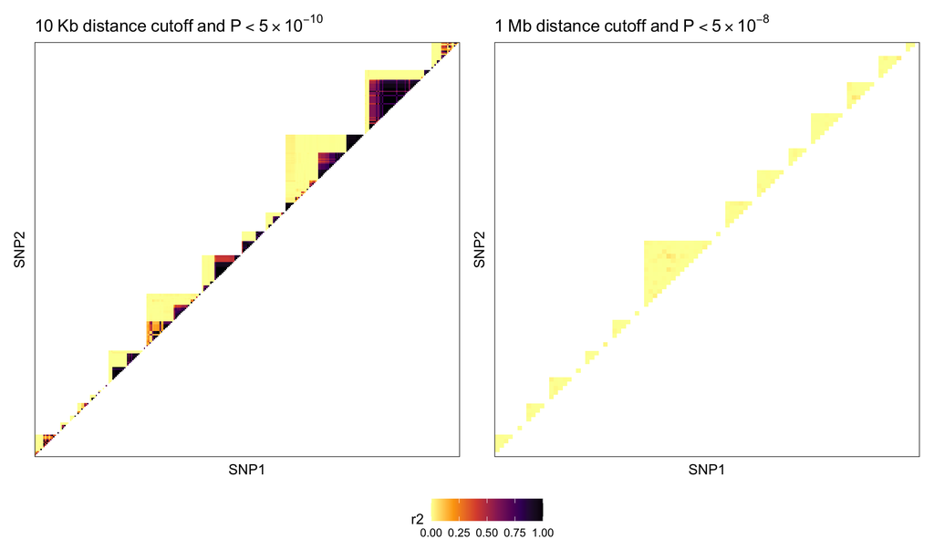

```r
# make plot
p1 <- ld_mat_tb %>%
  filter(grepl("Kb", dist_cutoff)) %>%
  ggplot(aes(SNP1, SNP2)) +
  geom_tile(aes(fill = r2)) +
  scale_fill_viridis_c(
    na.value = NA, direction = -1, option = 3, limits = c(0, 1)
    ) +
  theme_bw() +
  theme(
    axis.ticks = element_blank(),
    axis.text = element_blank(),
    panel.grid = element_blank(),
    strip.background = element_blank()
  ) +
  labs(
    title = expression(10~Kb~distance~cutoff~and~P<5%*%10^-10)
  )


p2 <- ld_mat_tb %>%
  filter(grepl("Mb", dist_cutoff)) %>%
  mutate(
    SNP1 = factor(SNP1, levels = unique(SNP1)),
    SNP2 = factor(SNP2, levels = unique(SNP2)),
  ) %>%
  ggplot(aes(SNP1, SNP2)) +
  geom_tile(aes(fill = r2)) +
  scale_fill_viridis_c(
    na.value = NA, direction = -1, option = 3, limits = c(0, 1)
    ) +
  theme_bw() +
  theme(
    axis.ticks = element_blank(),
    axis.text = element_blank(),
    panel.grid = element_blank(),
    strip.background = element_blank()
  ) +
  labs(
    title = expression(1~Mb~distance~cutoff~and~P<5%*%10^-8)
  )

p1 + p2 + plot_layout(guides='collect') &
  theme(legend.position='bottom')
```

Here we list SNP pairs, for which r<sup>2</sup> values are equal to one!

```r
ld_mat_tb %>%
  filter(r2 == 1) %>%
  as.data.frame()
```

```
##                     dist_cutoff chr        SNP1        SNP2 r2
## 1   10 Kb and P < 5e-10 cutoff    1  rs11578225  rs11581918  1
## 2   10 Kb and P < 5e-10 cutoff    1 rs145163454 rs144737447  1
## 3   10 Kb and P < 5e-10 cutoff    1 rs145163454   rs2227246  1
## 4   10 Kb and P < 5e-10 cutoff    1 rs144737447   rs2227246  1
## 5   10 Kb and P < 5e-10 cutoff    1  rs77979353  rs10800428  1
## 6   10 Kb and P < 5e-10 cutoff    1 rs145163454   rs1209731  1
## 7   10 Kb and P < 5e-10 cutoff    1 rs144737447   rs1209731  1
## 8   10 Kb and P < 5e-10 cutoff    1   rs2227246   rs1209731  1
## 9   10 Kb and P < 5e-10 cutoff    1   rs1894692      rs6025  1
## 10  10 Kb and P < 5e-10 cutoff   12  rs74097857  rs11176001  1
## 11  10 Kb and P < 5e-10 cutoff   13   rs1262776   rs1626445  1
## 12  10 Kb and P < 5e-10 cutoff   15  rs17293632  rs56062135  1
## 13  10 Kb and P < 5e-10 cutoff    2 rs113645544   rs7575552  1
## 14  10 Kb and P < 5e-10 cutoff    2  rs57640566  rs79433506  1
```

[output cut: 292 more lines]

Here we calculate average r<sup>2</sup> value among the SNPs (IVs).

```r
ld_mat_tb %>%
  group_by(dist_cutoff) %>%
  summarise(avg_r2 = mean(r2, na.rm = TRUE))
```

```
## # A tibble: 2 × 2
##   dist_cutoff                    avg_r2
##   <fct>                           <dbl>
## 1 "10 Kb and P < 5e-10 cutoff " 0.274
## 2 "1 Mb and P < 5e-8 cutoff"    0.00558
```

```r
ld_mat_tb %>%
  filter(!grepl("Kb", dist_cutoff)) %>%
  group_by(dist_cutoff) %>%
  top_n(n=3, wt = r2)
```

```
## # A tibble: 3 × 5
## # Groups:   dist_cutoff [1]
##   dist_cutoff              chr   SNP1      SNP2          r2
##   <fct>                    <fct> <fct>     <fct>      <dbl>
## 1 1 Mb and P < 5e-8 cutoff 2     rs4671051 rs7423637  0.038
## 2 1 Mb and P < 5e-8 cutoff 2     rs4671051 rs13017210 0.056
## 3 1 Mb and P < 5e-8 cutoff 7     rs7795564 rs3757582  0.049
```